# Actualización datos ley 23737

SNEEP cargo los datos de 2019. Hay que actualizar la misma info q teniamos hasta 2018. - https://github.com/datos-justicia-argentina/Sistema-Nacional-de-Estadisticas-sobre-Ejecucion-de-la-Pena-SNEEP/blob/master/Sistema-Nacional-de-Estadisticas-sobre-Ejecucion-de-la-Pena-SNEEP-metadata.md - http://datos.jus.gob.ar/dataset/sneep

```r
library(dplyr)
library(ggplot2)
library(readr)
library(tidyr)
library(openxlsx)

# sneep <- read_csv("C:/Users/Usuario/Desktop/Lucas/1- pe/7- ley 23737/data/sneep-unificado-2002-2019.csv")
# sneep <- read_csv("/Users/lucaspecina/Desktop/Data/Planificacion Estrategica/costo_ley23737_pba/datos complementarios/sneep-unificado-2002-2019.csv")
```

## Datasets generales a usar

- provinciales : todos delitos, todas provincias (seleccionadas)
- pba : todos delitos, PBA
- ley23737_pba : delitos 23737, PBA
- ley23737_provs : delitos 23737, todas las provincias (seleccionadas)
- NO23737_provs : delitos menos 23737, todas las provincias (seleccionadas)
- todos_2019 : todos los delitos de todas las provincias (no solo seleccionadas)

```r
# esto deja solo las provinciales
provinciales <- sneep %>%
  filter(reparticion_descripcion=='Provincial') %>%
  filter(
    (provincia_descripcion=='Buenos Aires' & anio_censo>=2005) |
                (provincia_descripcion=='Chaco' & anio_censo>=2015) |
                (provincia_descripcion=='Córdoba' & anio_censo>=2012) |
                (provincia_descripcion=='Formosa' & anio_censo>=2015) |
                (provincia_descripcion=='Salta' & anio_censo>=2014) |
                (provincia_descripcion=='Entre Rios' & anio_censo>=2018) |
                (provincia_descripcion=='Santiago del Estero' & anio_censo>=2018)) %>%
  mutate(DELITO = ifelse(delito1_descripcion=='Infracción ley n° 23.737 (estupefacientes)','23737','No_23737'))
```

#### Exploratorio de Provinciales (ver NAs y eso)

```r
provinciales %>% filter(anio_censo>=2018) %>% filter(provincia_descripcion == 'Buenos Aires') %>%
  filter(is.na(delito1_descripcion)) %>% pull(delito1_descripcion) %>% length()
```

```
[1] 608
```

#### Exploratorio - Tabla posiciones de delitos por provincias 2019 (todas no solo seleccionadas)

```r
# aca veo la distribucion de los delitos en delito1 cuando en delito2 es droga
todos_2019 %>% filter(delito2_descripcion=='Infracción ley n° 23.737 (estupefacientes)') %>%
  group_by(delito1_descripcion) %>% summarise(cantidad= n()) %>% arrange(desc(cantidad))

todos_2019 %>%


posiciones_delitos_2019 <- todos_2019 %>% group_by(provincia_descripcion, delito1_descripcion) %>% summarise(cantidad= n()) %>% arrange(desc(provincia_descripcion, cantidad))


posiciones_delitos_2019 <- posiciones_delitos_2019 %>% group_by(provincia_descripcion) %>% mutate(porcentaje= cantidad/sum(cantidad)) %>% arrange(provincia_descripcion)

# reformar df long to wide -> spread / pivot_wider()
posiciones_delitos_2019 <- posiciones_delitos_2019 %>% pivot_wider(id_cols= delito1_descripcion, names_from=provincia_descripcion, values_from= porcentaje) %>%
  mutate(across(everything(), ~replace_na(.x, 0)))

posiciones_delitos_2019
#write.xlsx(posiciones_delitos_2019, '/Users/lucaspecina/Desktop/Data/Planificacion Estrategica/costo_ley23737_pba/resultados complementarios/posiciones_delitos_2019.xlsx', na = "0")
```

#### Exploratorio - Tabla posiciones de delitos por provincias 2018 (todas no solo seleccionadas)

```r
posiciones_delitos_2018 <- todos_2018 %>% group_by(provincia_descripcion, delito1_descripcion) %>% summarise(cantidad= n()) %>% arrange(desc(provincia_descripcion, cantidad))


posiciones_delitos_2018 <- posiciones_delitos_2018 %>% group_by(provincia_descripcion) %>% mutate(porcentaje= cantidad/sum(cantidad)) %>% arrange(provincia_descripcion)

# reformar df long to wide -> spread / pivot_wider()
posiciones_delitos_2018 <- posiciones_delitos_2018 %>% pivot_wider(id_cols= delito1_descripcion, names_from=provincia_descripcion, values_from= porcentaje) %>%
  mutate(across(everything(), ~replace_na(.x, 0)))

posiciones_delitos_2018
#write.xlsx(posiciones_delitos_2018, '/Users/lucaspecina/Desktop/Data/Planificacion Estrategica/costo_ley23737_pba/resultados complementarios/posiciones_delitos_2018.xlsx', na = "0")
```

## Analisis basicos para la PBA

#### Cantidad de presos totales por año

```r
# cantidad de presos totales
presos_total_por_anio <- pba %>% group_by(anio_censo) %>% summarise(presos_totales= n())
# cantidad de presos por ley23737
presos_ley23737_por_anio <- ley23737_pba %>% group_by(anio_censo) %>% summarise(presos_ley23737= n())
# joineo
presos_porcen23737_por_anio <- presos_total_por_anio %>% inner_join(presos_ley23737_por_anio, by='anio_censo')
# calculo porcentaje
presos_porcen23737_por_anio <- presos_porcen23737_por_anio %>% mutate(porcen_ley23737 = (presos_ley23737/presos_totales))

print(presos_porcen23737_por_anio)

#write.csv(presos_porcen23737_por_anio, '/Users/lucaspecina/Desktop/Data/Planificacion Estrategica/costo_ley23737_pba/costo_ley23737_pba/spb/presos_porcen23737_por_anio.csv',row.names = FALSE)
```

#### Cantidad de presos por 23737 por año

```r
data_plot <- presos_porcen23737_por_anio %>% pivot_longer(c(presos_totales,presos_ley23737), names_to='tipo', values_to='cantidad')

ggplot(data_plot, aes(x=anio_censo,y=cantidad,color=tipo)) + geom_line() + geom_point() +
    labs(title="Provincia de Buenos Aires",x="Año de censo", y = "Cantidad de presos")
```

Analisis para provincias seleccionadas pero solo 2019

```r
# cantidad de presos totales por año y provincia
presos_total_por_prov_19 <- provinciales %>% filter(anio_censo==2019) %>% group_by(provincia_descripcion) %>%
  summarise(presos_totales= n())

# cantidad de presos droga por año y provincia
presos_ley23737_por_prov_19 <- ley23737_provs %>% filter(anio_censo==2019) %>% group_by(provincia_descripcion) %>%
  summarise(presos_ley23737= n())

# joineo
presos_porcen23737_por_prov_19 <- presos_total_por_prov_19 %>%
  inner_join(presos_ley23737_por_prov_19, by=c('provincia_descripcion')) %>%
  mutate(porcentaje_ley23737= presos_ley23737/presos_totales)

#write.xlsx(presos_porcen23737_por_prov_19,'/Users/lucaspecina/Desktop/Data/Planificacion Estrategica/costo_ley23737_pba/resultados complementarios/presos_porcen23737_2019.xlsx',row.names = FALSE)
```

Analisis para provincias seleccionadas pero solo 2018

```r
# cantidad de presos totales por año y provincia
presos_total_por_prov_18 <- provinciales %>% filter(anio_censo==2018) %>% group_by(provincia_descripcion) %>%
  summarise(presos_totales= n())

# cantidad de presos droga por año y provincia
presos_ley23737_por_prov_18 <- ley23737_provs %>% filter(anio_censo==2018) %>% group_by(provincia_descripcion) %>%
  summarise(presos_ley23737= n())

# joineo
presos_porcen23737_por_prov_18 <- presos_total_por_prov_18 %>%
  inner_join(presos_ley23737_por_prov_18, by=c('provincia_descripcion')) %>%
  mutate(porcentaje_ley23737= presos_ley23737/presos_totales)

#write.xlsx(presos_porcen23737_por_prov_18,'/Users/lucaspecina/Desktop/Data/Planificacion Estrategica/costo_ley23737_pba/resultados complementarios/presos_porcen23737_2018.xlsx',row.names = FALSE)
```

## Analisis para todas las provincias (DROGA Y NO DROGA)

#### Cantidad de presos NO DROGA y por droga, por año y provincia

[output not shown]

[output cut: 33 more lines]

```r
print(cantidad_presos_anio_prov)
```

#### Graficar por separado (facet) la evolucion del cambio porcentual de presos NO DROGA y por 23737

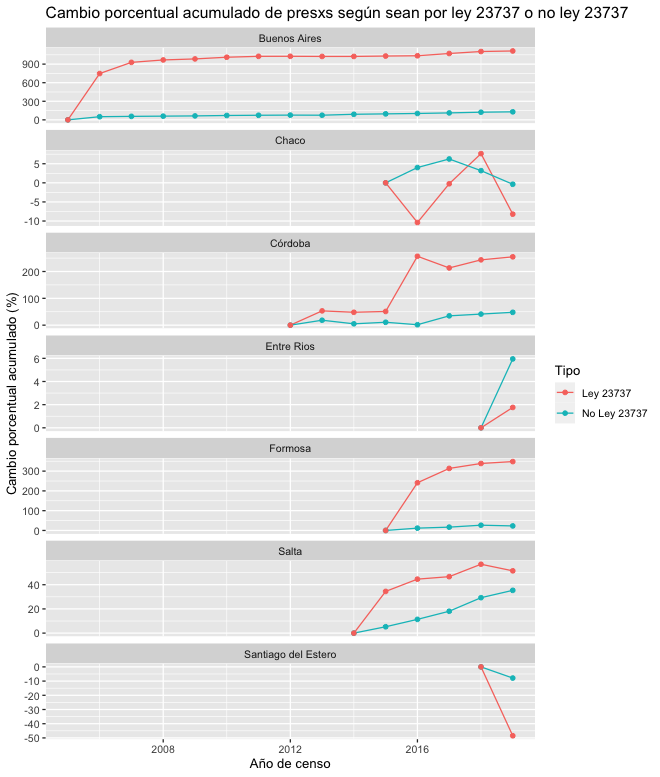

## Analisis para todas las provincias (DROGA Y TOTAL)

#### Cantidad de presos totales y por droga, por año y provincia

```r
# cantidad de presos totales por año y provincia
presos_total_por_anio_prov <- provinciales %>% group_by(anio_censo,provincia_descripcion) %>%
  summarise(presos_totales= n())
# cantidad de presos droga por año y provincia
presos_ley23737_por_anio_prov <- ley23737_provs %>% group_by(anio_censo,provincia_descripcion) %>%
  summarise(presos_ley23737= n())
# joineo
presos_porcen23737_por_anio_prov <- presos_total_por_anio_prov %>%
  inner_join(presos_ley23737_por_anio_prov, by=c('anio_censo','provincia_descripcion'))

# calculo porcentaje
presos_porcen23737_por_anio_prov <- presos_porcen23737_por_anio_prov %>%
  mutate(porcen_ley23737 = (presos_ley23737/presos_totales))

# calculo cambios porcentuales por año
presos_porcen23737_por_anio_prov <- presos_porcen23737_por_anio_prov %>% group_by(provincia_descripcion) %>%
  mutate(cambioporc_totales = (presos_totales-lag(presos_totales))/lag(presos_totales) ,
         cambioporc_23737 = (presos_ley23737-lag(presos_ley23737))/lag(presos_ley23737))

# cambio porcentual acumulado
presos_porcen23737_por_anio_prov <- presos_porcen23737_por_anio_prov %>% group_by(provincia_descripcion) %>%
  mutate(cambioporc_totales_acum = cumsum(replace_na(cambioporc_totales,0)),
         cambioporc_23737_acum = cumsum(replace_na(cambioporc_23737,0)))

#write.xlsx(presos_porcen23737_por_anio_prov, '/Users/lucaspecina/Desktop/Data/Planificacion Estrategica/costo_ley23737_pba/resultados complementarios/presos_porcen23737_por_anio_prov.xlsx',row.names = FALSE)
# despues sigo en excel haciendo los cambios porcentuales, etc.


print(presos_porcen23737_por_anio_prov)
```

| anio_censo | provincia_descripcion | presos_totales | presos_ley23737 | porcen_ley23737 | cambioporc_totales | cambioporc_23737 | cambioporc_totales_acum | cambioporc_23737_acum |
| --- | --- | --- | --- | --- | --- | --- | --- | --- |
| 2005 | Buenos Aires | 12987 | 44 | 0.003388003 | NA | NA | 0.000000000 | 0.000000000 |
| 2006 | Buenos Aires | 20306 | 373 | 0.018368955 | 0.563563564 | 7.477272727 | 0.563563564 | 7.477272727 |
| 2007 | Buenos Aires | 21859 | 1047 | 0.047897891 | 0.076479858 | 1.806970509 | 0.640043422 | 9.284243237 |
| 2008 | Buenos Aires | 23049 | 1455 | 0.063126383 | 0.054439819 | 0.389684814 | 0.694483241 | 9.673928050 |
| 2009 | Buenos Aires | 23015 | 1695 | 0.073647621 | -0.001475118 | 0.164948454 | 0.693008122 | 9.838876504 |
| 2010 | Buenos Aires | 26593 | 2161 | 0.081261986 | 0.155463828 | 0.274926254 | 0.848471950 | 10.113802758 |
| 2011 | Buenos Aires | 27066 | 2473 | 0.091369246 | 0.017786636 | 0.144377603 | 0.866258586 | 10.258180361 |
| 2012 | Buenos Aires | 26888 | 2490 | 0.092606367 | -0.006576517 | 0.006874242 | 0.859682069 | 10.265054602 |
| 2012 | Córdoba | 6307 | 340 | 0.053908356 | NA | NA | 0.000000000 | 0.000000000 |
| 2013 | Buenos Aires | 28094 | 2432 | 0.086566527 | 0.044852722 | -0.023293173 | 0.904534792 | 10.241761430 |

[output cut: 33 more lines]

```r
NA
```

#### Graficar

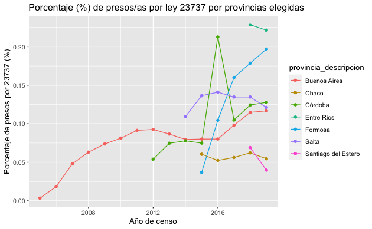

```r
ggplot(presos_porcen23737_por_anio_prov, aes(x=anio_censo,y=porcen_ley23737,color=provincia_descripcion)) + geom_line() + geom_point() +
    labs(title="Porcentaje (%) de presos/as por ley 23737 por provincias elegidas",x="Año de censo", y = "Porcentaje de presos por 23737 (%)")
```

#### Graficar por separado (facet)

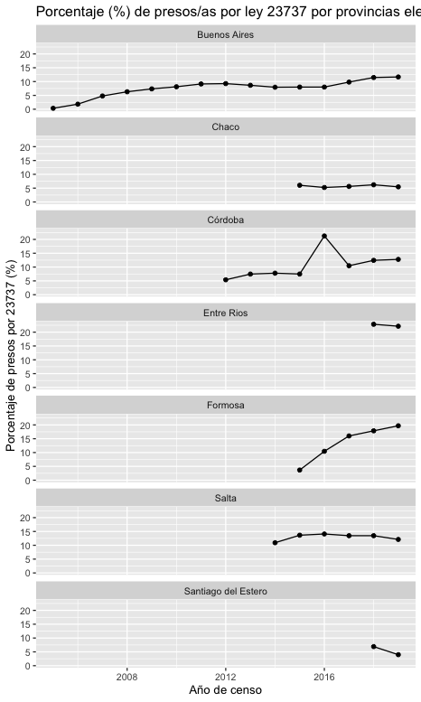

```r
ggplot(presos_porcen23737_por_anio_prov, aes(x=anio_censo,y=porcen_ley23737*100)) + geom_line() + geom_point() +
    labs(title="Porcentaje (%) de presos/as por ley 23737 por provincias elegidas",x="Año de censo", y = "Porcentaje de presos por 23737 (%)") + facet_wrap(vars(provincia_descripcion), ncol=1)
```

```r
NA
NA
```

#### Graficar por separado (facet) la evolucion del cambio porcentual de presos totales y por 23737

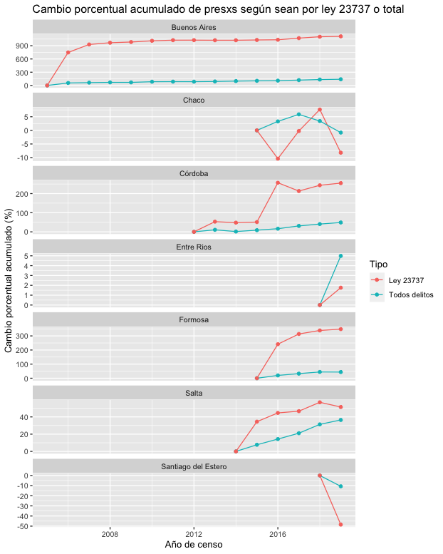

```r
# acumulado
data_plot_pctch <- presos_porcen23737_por_anio_prov %>%
  mutate(cambioporc_totales_acum = cambioporc_totales_acum*100,
         cambioporc_23737_acum = cambioporc_23737_acum*100)
data_plot_pctch <- data_plot_pctch %>%
  pivot_longer(c(cambioporc_totales_acum,cambioporc_23737_acum), names_to='Tipo',values_to='Porcentaje') %>%
  mutate(Tipo= ifelse(Tipo=='cambioporc_totales_acum','Todos delitos','Ley 23737'))

ggplot(data_plot_pctch, aes(x=anio_censo,y=Porcentaje, color=Tipo)) + geom_line() + geom_point() +
    labs(title="Cambio porcentual acumulado de presxs según sean por ley 23737 o total",x="Año de censo", y = "Cambio porcentual acumulado (%)") + facet_wrap(vars(provincia_descripcion), ncol=1, scales = "free_y")
```

```r
NA
NA
```

POR GENERO (NO DROGA Y DROGA)

```r
# agrupo todo junto (año, prov y delito (droga y no droga))
cantidad_presos_anio_prov <- provinciales %>% group_by(anio_censo,provincia_descripcion,genero_descripcion,DELITO) %>%
  summarise(cantidad= n())
```

[figure not shown]

## Por provincia y por genero

Le agrego cuatro columnas : mujeres_total, mujeres_droga, varones_total, varones_droga

#### Presos totales y droga, por año, provincia y genero

Los de genero no tienen NAs asi que PRUEBO que sumas de categorias sea igual a presos_totales/ley23737

```r
## PRUEBAS NA
# bien, no tiene NAs


# cantidad de presos totales
presos_total_por_anio_prov <- provinciales %>%
  group_by(anio_censo,provincia_descripcion) %>%
  summarise(presos_totales= n())
# cantidad de presos droga por año y provincia
presos_ley23737_por_anio_prov <- ley23737_provs %>%
  group_by(anio_censo,provincia_descripcion) %>%
  summarise(presos_ley23737= n())
# joineo
presos_porcen23737_por_anio_prov <- presos_total_por_anio_prov %>%
  inner_join(presos_ley23737_por_anio_prov, by=c('anio_censo','provincia_descripcion'))


# POR GENERO
# total mujeres
mujeres_total <- provinciales %>% filter(genero_descripcion=='Femenino') %>%
  group_by(anio_censo,provincia_descripcion) %>%
  summarise(mujeres_total= n())
presos_porcen23737_por_anio_prov <- presos_porcen23737_por_anio_prov %>%
  left_join(mujeres_total,by=c('anio_censo','provincia_descripcion'))

# droga mujeres
mujeres_droga <- ley23737_provs %>% filter(genero_descripcion=='Femenino') %>%
  group_by(anio_censo,provincia_descripcion) %>%
  summarise(mujeres_droga= n())
presos_porcen23737_por_anio_prov <- presos_porcen23737_por_anio_prov %>%
  left_join(mujeres_droga,by=c('anio_censo','provincia_descripcion'))

# total varones
varones_total <- provinciales %>% filter(genero_descripcion=='Masculino') %>%
  group_by(anio_censo,provincia_descripcion) %>%
  summarise(varones_total= n())
presos_porcen23737_por_anio_prov <- presos_porcen23737_por_anio_prov %>%
  left_join(varones_total,by=c('anio_censo','provincia_descripcion'))

# droga varones
varones_droga <- ley23737_provs %>% filter(genero_descripcion=='Masculino') %>%
  group_by(anio_censo,provincia_descripcion) %>%
  summarise(varones_droga= n())
presos_porcen23737_por_anio_prov <- presos_porcen23737_por_anio_prov %>%
  left_join(varones_droga,by=c('anio_censo','provincia_descripcion'))

# total transexuales
transexual_total <- provinciales %>% filter(genero_descripcion=='Transexual') %>%
  group_by(anio_censo,provincia_descripcion) %>%
  summarise(transexual_total= n())
presos_porcen23737_por_anio_prov <- presos_porcen23737_por_anio_prov %>%
  left_join(transexual_total,by=c('anio_censo','provincia_descripcion'))

# droga transexuales
transexual_droga <- ley23737_provs %>% filter(genero_descripcion=='Transexual') %>%
  group_by(anio_censo,provincia_descripcion) %>%
  summarise(transexual_droga= n())
presos_porcen23737_por_anio_prov <- presos_porcen23737_por_anio_prov %>%
  left_join(transexual_droga,by=c('anio_censo','provincia_descripcion'))


# reemplazo los NA con 0
presos_porcen23737_por_anio_prov <- presos_porcen23737_por_anio_prov %>% replace(is.na(.), 0)


## PRUEBAS SUMAS
# bien, da igual


# calculo porcentajes (sin *100)
presos_porcen23737_por_anio_prov <- presos_porcen23737_por_anio_prov %>%
  mutate(porcen_ley23737 = (presos_ley23737/presos_totales))

# de total de GENERO, cuantas son por droga
presos_porcen23737_por_anio_prov <- presos_porcen23737_por_anio_prov %>% mutate(
      mujeres_porcen_droga = mujeres_droga/mujeres_total,
      varones_porcen_droga = varones_droga/varones_total,
      transexuales_porcen_droga = transexual_droga/transexual_total)
# del total de delitos, que porcentaje por genero
presos_porcen23737_por_anio_prov <- presos_porcen23737_por_anio_prov %>% mutate(
      total_porcen_mujeres = mujeres_total/(mujeres_total+varones_total+transexual_total),
      total_porcen_varones = varones_total/(mujeres_total+varones_total+transexual_total),
      total_porcen_transexuales = transexual_total/(mujeres_total+varones_total+transexual_total))
# de delitos droga, que porcentaje por genero
presos_porcen23737_por_anio_prov <- presos_porcen23737_por_anio_prov %>% mutate(
      droga_porcen_mujeres = mujeres_droga/(mujeres_droga+varones_droga+transexual_droga),
      droga_porcen_varones = varones_droga/(mujeres_droga+varones_droga+transexual_droga),
      droga_porcen_transexuales = transexual_droga/(mujeres_droga+varones_droga+transexual_droga))

# reemplazo los NA con 0
presos_porcen23737_por_anio_prov <- presos_porcen23737_por_anio_prov %>% replace(is.na(.), 0)

# calculo cambios porcentuales
presos_porcen23737_por_anio_prov <- presos_porcen23737_por_anio_prov %>% group_by(provincia_descripcion) %>%
  mutate(cambioporc_varones_total = (varones_total-lag(varones_total))/lag(varones_total),
         cambioporc_mujeres_total = (mujeres_total-lag(mujeres_total))/lag(mujeres_total),
         cambioporc_varones_23737 = (varones_droga-lag(varones_droga))/lag(varones_droga),
         cambioporc_mujeres_23737 = (mujeres_droga-lag(mujeres_droga))/lag(mujeres_droga))

# calculo cambios porcentuales acumulado
presos_porcen23737_por_anio_prov <- presos_porcen23737_por_anio_prov %>% group_by(provincia_descripcion) %>%
  mutate(cambioporc_acum_varones_total = cumsum(replace_na(cambioporc_varones_total,0)),
         cambioporc_acum_mujeres_total = cumsum(replace_na(cambioporc_mujeres_total,0)),
         cambioporc_acum_varones_23737 = cumsum(replace_na(cambioporc_varones_23737,0)),
         cambioporc_acum_mujeres_23737 = cumsum(replace_na(cambioporc_mujeres_23737,0)))



#write.xlsx(presos_porcen23737_por_anio_prov, '/Users/lucaspecina/Desktop/Data/Planificacion Estrategica/costo_ley23737_pba/resultados complementarios/presos_porcen23737_anio_provs_genero_cambio_acum.xlsx',row.names = FALSE)

presos_porcen23737_por_anio_prov
```

| anio_censo | provincia_descripcion | presos_totales | presos_ley23737 | mujeres_total | mujeres_droga | varones_total | varones_droga | transexual_total | transexual_droga | porcen_ley23737 | mujeres_porcen_droga | varones_porcen_droga | transexuales_porcen_droga | total_porcen_mujeres | total_porcen_varones | total_porcen_transexuales | droga_porcen_mujeres | droga_porcen_varones | droga_porcen_transexuales | cambioporc_varones_total | cambioporc_mujeres_total | cambioporc_varones_23737 | cambioporc_mujeres_23737 | cambioporc_acum_varones_total | cambioporc_acum_mujeres_total | cambioporc_acum_varones_23737 | cambioporc_acum_mujeres_23737 |
| --- | --- | --- | --- | --- | --- | --- | --- | --- | --- | --- | --- | --- | --- | --- | --- | --- | --- | --- | --- | --- | --- | --- | --- | --- | --- | --- | --- |
| 2005 | Buenos Aires | 12987 | 44 | 121 | 6 | 12866 | 38 | 0 | 0 | 0.003388003 | 0.04958678 | 0.002953521 | 0.0000000 | 0.009317009 | 0.9906830 | 0.0000000000 | 0.13636364 | 0.86363636 | 0.000000000 | NA | NA | NA | NA | 0.00000000 | 0.000000000 | 0.000000000 | 0.00000000 |
| 2006 | Buenos Aires | 20306 | 373 | 741 | 107 | 19565 | 266 | 0 | 0 | 0.018368955 | 0.14439946 | 0.013595707 | 0.0000000 | 0.036491677 | 0.9635083 | 0.0000000000 | 0.28686327 | 0.71313673 | 0.000000000 | 0.5206746464 | 5.123966942 | 6.000000000 | 16.83333333 | 0.52067465 | 5.123966942 | 6.000000000 | 16.83333333 |
| 2007 | Buenos Aires | 21859 | 1047 | 844 | 286 | 21015 | 761 | 0 | 0 | 0.047897891 | 0.33886256 | 0.036212229 | 0.0000000 | 0.038611098 | 0.9613889 | 0.0000000000 | 0.27316141 | 0.72683859 | 0.000000000 | 0.0741119346 | 0.139001350 | 1.860902256 | 1.67289720 | 0.59478658 | 5.262968292 | 7.860902256 | 18.50623053 |
| 2008 | Buenos Aires | 23049 | 1455 | 950 | 389 | 22099 | 1066 | 0 | 0 | 0.063126383 | 0.40947368 | 0.048237477 | 0.0000000 | 0.041216539 | 0.9587835 | 0.0000000000 | 0.26735395 | 0.73264605 | 0.000000000 | 0.0515822032 | 0.125592417 | 0.400788436 | 0.36013986 | 0.64636878 | 5.388560709 | 8.261690692 | 18.86637039 |
| 2009 | Buenos Aires | 23015 | 1695 | 938 | 403 | 22077 | 1292 | 0 | 0 | 0.073647621 | 0.42963753 | 0.058522444 | 0.0000000 | 0.040756029 | 0.9592440 | 0.0000000000 | 0.23775811 | 0.76224189 | 0.000000000 | -0.0009955202 | -0.012631579 | 0.212007505 | 0.03598972 | 0.64537326 | 5.375929130 | 8.473698197 | 18.90236011 |
| 2010 | Buenos Aires | 26593 | 2161 | 1079 | 433 | 25514 | 1728 | 0 | 0 | 0.081261986 | 0.40129750 | 0.067727522 | 0.0000000 | 0.040574587 | 0.9594254 | 0.0000000000 | 0.20037020 | 0.79962980 | 0.000000000 | 0.1556823844 | 0.150319829 | 0.337461300 | 0.07444169 | 0.80105565 | 5.526248959 | 8.811159497 | 18.97680179 |
| 2011 | Buenos Aires | 27066 | 2473 | 1176 | 506 | 25890 | 1967 | 0 | 0 | 0.091369246 | 0.43027211 | 0.075975280 | 0.0000000 | 0.043449346 | 0.9565507 | 0.0000000000 | 0.20460979 | 0.79539021 | 0.000000000 | 0.0147370071 | 0.089898054 | 0.138310185 | 0.16859122 | 0.81579266 | 5.616147013 | 8.949469682 | 19.14539302 |
| 2012 | Buenos Aires | 26888 | 2490 | 1179 | 545 | 25709 | 1945 | 0 | 0 | 0.092606367 | 0.46225615 | 0.075654440 | 0.0000000 | 0.043848557 | 0.9561514 | 0.0000000000 | 0.21887550 | 0.78112450 | 0.000000000 | -0.0069911163 | 0.002551020 | -0.011184545 | 0.07707510 | 0.80880154 | 5.618698033 | 8.938285137 | 19.22246812 |
| 2012 | Córdoba | 6307 | 340 | 222 | 37 | 6085 | 303 | 0 | 0 | 0.053908356 | 0.16666667 | 0.049794577 | 0.0000000 | 0.035198985 | 0.9648010 | 0.0000000000 | 0.10882353 | 0.89117647 | 0.000000000 | NA | NA | NA | NA | 0.00000000 | 0.000000000 | 0.000000000 | 0.00000000 |
| 2013 | Buenos Aires | 28094 | 2432 | 1119 | 413 | 26975 | 2019 | 0 | 0 | 0.086566527 | 0.36907954 | 0.074847081 | 0.0000000 | 0.039830569 | 0.9601694 | 0.0000000000 | 0.16981908 | 0.83018092 | 0.000000000 | 0.0492434556 | -0.050890585 | 0.038046272 | -0.24220183 | 0.85804499 | 5.567807448 | 8.976331410 | 18.98026628 |

[output cut: 33 more lines]

#### plots genero 2019

Armar uno o un par de gráficos donde se observe con claridad:

- El altísimo porcentaje de mujeres que están presas por estos delitos sobre el total de mujeres presas; en algunos casos, como por ejemplo, entre ríos es el 60%.
- Que el porcentaje de mujeres en delitos ley 23.737 es mayor al porcentaje general en la relación varones/mujeres privadxs de libertad;

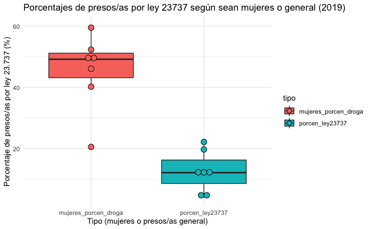

```r
data_plot_genero <- presos_porcen23737_por_anio_prov %>% filter(anio_censo==2019) %>%
  mutate(porcen_ley23737 = porcen_ley23737*100,
         mujeres_porcen_droga = mujeres_porcen_droga*100)
data_plot_genero <- data_plot_genero %>%
  pivot_longer(c(porcen_ley23737,mujeres_porcen_droga), names_to='tipo', values_to='cantidad')

ggplot(data_plot_genero, aes(x=tipo, y=cantidad, fill=tipo)) + geom_boxplot(notch=FALSE) +
  geom_dotplot(binaxis='y', stackdir='center', dotsize=1) +
  labs(title="Porcentajes de presos/as por ley 23737 según sean mujeres o general (2019)",x="Tipo (mujeres o presos/as general)", y = "Porcentaje de presos/as por ley 23.737 (%)") + theme_minimal()
```

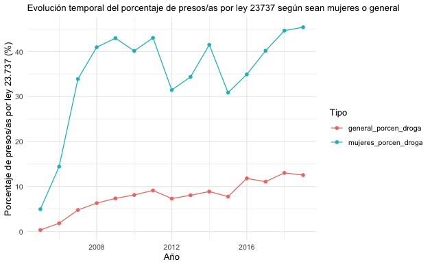

```r
###

data_plot_genero <- presos_porcen23737_por_anio_prov %>%
  mutate(porcen_ley23737 = porcen_ley23737*100,
         mujeres_porcen_droga = mujeres_porcen_droga*100)
data_plot_genero <- data_plot_genero %>%
  group_by(anio_censo) %>% summarise(mujeres_porcen_droga = mean(mujeres_porcen_droga),
                                     general_porcen_droga = mean(porcen_ley23737)) %>%
  pivot_longer(c(mujeres_porcen_droga,general_porcen_droga), names_to='Tipo',values_to='Porcentaje')
ggplot(data_plot_genero, aes(x=anio_censo, y=Porcentaje, color=Tipo)) + geom_line() + geom_point() +
  labs(title="Evolución temporal del porcentaje de presos/as por ley 23737 según sean mujeres o general",x="Año", y = "Porcentaje de presos/as por ley 23.737 (%)")  + theme_minimal() + theme(plot.title = element_text(size=11))
```

```r
NA
NA
```

#### Graficar por separado (facet)

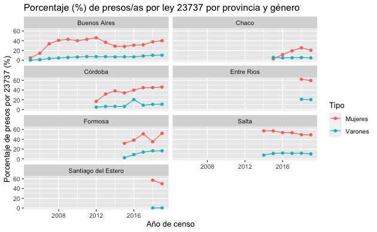

```r
data_plot_genero <- presos_porcen23737_por_anio_prov %>%
  mutate(varones_porcen_droga = varones_porcen_droga*100,
         mujeres_porcen_droga = mujeres_porcen_droga*100)
data_plot_genero <- data_plot_genero %>%
  pivot_longer(c(mujeres_porcen_droga,varones_porcen_droga), names_to='Tipo',values_to='Porcentaje') %>%
  mutate(Tipo= ifelse(Tipo=='mujeres_porcen_droga','Mujeres','Varones'))



ggplot(data_plot_genero, aes(x=anio_censo,y=Porcentaje, color=Tipo)) + geom_line() + geom_point() +
    labs(title="Porcentaje (%) de presos/as por ley 23737 por provincia y género",x="Año de censo", y = "Porcentaje de presos por 23737 (%)") + facet_wrap(vars(provincia_descripcion), ncol=2)
```

## Procesados y condenados por droga y no droga

Primero saco los otros que no sean condenados y procesados y a eso le aplico lo de provinciales

```r
provinciales_proce_conde <- sneep %>% filter((situacion_legal_descripcion=='Procesado') | (situacion_legal_descripcion=='Condenado')) %>%
  filter(anio_censo>=2005 & reparticion_descripcion=='Provincial') %>%
    filter(
    (provincia_descripcion=='Buenos Aires') |
      (provincia_descripcion=='Chaco' & anio_censo>=2015) |
      (provincia_descripcion=='Córdoba' & anio_censo>=2012) |
      (provincia_descripcion=='Formosa' & anio_censo>=2015) |
      (provincia_descripcion=='Salta' & anio_censo>=2014) |
      (provincia_descripcion=='Entre Rios' & anio_censo>=2018) |
      (provincia_descripcion=='Santiago del Estero' & anio_censo>=2018))

# BA_proce_conde <- sneep %>% filter((situacion_legal_descripcion=='Procesado') | (situacion_legal_descripcion=='Condenado')) %>%
#   filter(anio_censo>=2006 & reparticion_descripcion=='Provincial' & provincia_descripcion=='Buenos Aires') %>%
#   select(c(es_reincidente_id,es_reincidente_descripcion))
```

Dejo solo los que no son de drogas

```r
nrow(provinciales_proce_conde %>% filter(anio_censo>=2018)) # 122652
```

```
[1] 122652
```

```r
provinciales_proce_conde %>% filter(anio_censo>=2018) %>%
  filter(is.na(delito1_descripcion)) %>% pull(delito1_descripcion) %>% length() # 1549
```

```
[1] 1549
```

```r
# la cantidad de NA en delito1 es muy poco, por lo tanto puedo trabajar bien

# delitos por NO ley 23737
NOdroga_provs <- provinciales_proce_conde %>%
  filter(
    ((delito1_descripcion!='Infracción ley n° 23.737 (estupefacientes)')))
```

Saco los numeros y porcentajes de procesados para los no droga

```r
procesados_NOdroga <- NOdroga_provs %>% filter(situacion_legal_descripcion=='Procesado') %>%
  group_by(anio_censo,provincia_descripcion) %>% summarise(procesados_NOdroga= n())
condenados_NOdroga <- NOdroga_provs %>% filter(situacion_legal_descripcion=='Condenado') %>%
  group_by(anio_censo,provincia_descripcion) %>% summarise(condenados_NOdroga= n())
# join
procesados_porcen_NOdroga <- procesados_NOdroga %>% inner_join(condenados_NOdroga, by=c('anio_censo','provincia_descripcion'))
# calculo porcentajes
procesados_porcen_NOdroga <- procesados_porcen_NOdroga %>% mutate(procesados_porcen_NOdroga = procesados_NOdroga/(procesados_NOdroga+condenados_NOdroga))
```

Dejo solo los que son de drogas

```r
# delitos por ley 23737
droga_provs <- provinciales_proce_conde %>%
    filter(delito1_descripcion=='Infracción ley n° 23.737 (estupefacientes)' )
```

```r
# hago un fix : agrego formosa 2015 y 2016 que quedan vacios porque no tienen ninguno. Les agrego 0 (rbind)
condenados_droga <- condenados_droga %>% add_row(anio_censo=2015,provincia_descripcion='Formosa',condenados_droga=0)
```

[output not shown]

Joineo los resultados de drogas y no drogas

```r
procesados_porcen_todos <- procesados_porcen_droga %>% inner_join(procesados_porcen_NOdroga, by=c('anio_censo','provincia_descripcion'))

# hago la resta
procesados_porcen_todos <- procesados_porcen_todos %>% mutate(diferencia_procesados = procesados_porcen_droga - procesados_porcen_NOdroga)

procesados_porcen_todos
```

| anio_censo | provincia_descripcion | procesados_droga | condenados_droga | procesados_porcen_droga | procesados_NOdroga | condenados_NOdroga | procesados_porcen_NOdroga | diferencia_procesados |
| --- | --- | --- | --- | --- | --- | --- | --- | --- |
| 2005 | Buenos Aires | 32 | 12 | 0.7272727 | 9832 | 2275 | 0.81209218 | -8.481945e-02 |
| 2006 | Buenos Aires | 363 | 10 | 0.9731903 | 14184 | 3963 | 0.78161680 | 1.915736e-01 |
| 2007 | Buenos Aires | 981 | 60 | 0.9423631 | 14888 | 4244 | 0.77817269 | 1.641904e-01 |
| 2008 | Buenos Aires | 1250 | 201 | 0.8614748 | 14870 | 5021 | 0.74757428 | 1.139006e-01 |
| 2009 | Buenos Aires | 1285 | 397 | 0.7639715 | 13986 | 6708 | 0.67584807 | 8.812339e-02 |
| 2010 | Buenos Aires | 1593 | 565 | 0.7381835 | 13396 | 8727 | 0.60552366 | 1.326598e-01 |
| 2011 | Buenos Aires | 1724 | 734 | 0.7013832 | 12896 | 10029 | 0.56252999 | 1.388532e-01 |
| 2012 | Buenos Aires | 1730 | 721 | 0.7058344 | 13076 | 10462 | 0.55552723 | 1.503071e-01 |
| 2012 | Córdoba | 270 | 70 | 0.7941176 | 2641 | 2810 | 0.48449826 | 3.096194e-01 |
| 2013 | Buenos Aires | 1570 | 824 | 0.6558062 | 12212 | 10926 | 0.52778978 | 1.280164e-01 |

[output cut: 31 more lines]

```r
#write.xlsx(procesados_porcen_todos, '/Users/lucaspecina/Desktop/Data/Planificacion Estrategica/costo_ley23737_pba/resultados complementarios/proce_conde_porcen_todos.xlsx',row.names = FALSE)
```

#### Graficar por separado (facet) la evolucion de porcentaje de procesados por provs

[figure not shown]

```r
# graficos de lineas (con la diferencia entre porcentajes de procesados por droga y no droga)
ggplot(procesados_porcen_todos, aes(x=anio_censo,y=diferencia_procesados,color=provincia_descripcion)) + geom_line() + geom_point() +
    labs(title="Diferencia de porcentajes de procesados entre drogas y no drogas",x="Año de censo", y = "Diferencia de porcentajes entre drogas y no drogas")

# para solo buenos aires (es un gather) saco el 2005 porq solo fue diciembre lo de drogas
data_plotear <- procesados_porcen_todos %>% filter(provincia_descripcion=='Buenos Aires' & anio_censo>= 2006) %>% gather(tipo_delito, porcentaje, c(procesados_porcen_droga,procesados_porcen_NOdroga),factor_key=TRUE)

ggplot(data_plotear, aes(x=anio_censo,y=porcentaje,color=tipo_delito)) + geom_line() + geom_point() +
    labs(title="Porcentajes de procesados entre drogas y no drogas (PBA)",x="Año de censo", y = "Porcentajes de procesados(%)")
```

```r
# prueba simple : evolucion de porcentaje de procesados generales
prueba_BA_proce <- provinciales %>% filter(provincia_descripcion=='Buenos Aires')


prueba_BA_proce_pro <- prueba_BA_proce %>% filter(situacion_legal_descripcion=='Procesado') %>%
  group_by(anio_censo) %>% summarise(procesados= n())

prueba_BA_proce_con <- prueba_BA_proce %>% filter(situacion_legal_descripcion=='Condenado') %>%
  group_by(anio_censo) %>% summarise(condenados= n())

# join
prueba_BA_proce <- prueba_BA_proce_pro %>% inner_join(prueba_BA_proce_con, by=c('anio_censo'))
# calculo porcentajes
prueba_BA_proce <- prueba_BA_proce %>% mutate(procesados_porcen = procesados/(procesados+condenados))

# write.csv(prueba_BA_proce, '/Users/lucaspecina/Desktop/Data/Planificacion Estrategica/costo_ley23737_pba/costo_ley23737_pba/spb/prueba_BA_proce.csv',row.names = FALSE)

ggplot(prueba_BA_proce, aes(x=anio_censo,y=procesados_porcen)) + geom_line() + geom_point() +
    labs(title="Diferencia de porcentajes de procesados PBA",x="Año de censo", y = "Porcentajes procesados")
```

## Porcentaje por ley 23737 por cada unidad

todos delitos

```r
# todos delitos
total_provs <- provinciales


# hago el agrupamiento tambien por unidad
total_unidades <- total_provs %>% group_by(anio_censo,provincia_descripcion, establecimiento_descripcion) %>%
      summarise(cantidad_total = n())
```

Droga dataset y agrupado

```r
# delitos por ley 23737
droga_provs <- ley23737_provs


droga_unidades <- droga_provs %>% group_by(anio_censo,provincia_descripcion, establecimiento_descripcion) %>%
      summarise(cantidad_droga = n())
```

Join y calculos

```r
unidades <- total_unidades %>% inner_join(droga_unidades, by=c('anio_censo','provincia_descripcion','establecimiento_descripcion'))

unidades <- unidades %>% mutate(prop_droga = cantidad_droga / cantidad_total )

unidades_pba_2019 <- unidades %>% filter(provincia_descripcion == 'Buenos Aires' & anio_censo==2019) %>% arrange(desc(cantidad_total))

#write.csv(unidades_pba_2019, '/Users/lucaspecina/Desktop/Data/Planificacion Estrategica/costo_ley23737_pba/costo_ley23737_pba/spb/unidades_pba_2019.csv')

# tomando las 20 unidades con mas presos, el porcentaje promedio de presos x droga es
mean(unidades_pba_2019 %>% head(20) %>% pull(prop_droga)) # 12.35 %

unidades_pba_2019
```

```r
ggplot(unidades_pba_2019 , aes(x=prop_droga)) + geom_histogram(aes(y=..density..), colour="black", fill="white") + geom_density(alpha=.2, fill="#FF6666") + geom_vline(aes(xintercept=mean(unidades_pba_2019$prop_droga)), color="blue", linetype="dashed", size=1) +
  scale_x_continuous(breaks = seq(0, 60, by = 5)) +
    labs(title="Distribución de los porcentajes de presos/as por droga por unidad",x="Porcentaje de presos/as por droga (%)", y = "Densidad (frecuencia relativa)")

ggplot(unidades_pba_2019 , aes(x=prop_droga)) + geom_histogram( colour="black", fill="white") + geom_vline(aes(xintercept=mean(unidades_pba_2019$prop_droga)), color="blue", linetype="dashed", size=1) +
  scale_x_continuous(breaks = seq(0, 60, by = 5))
```